# Practical Machine Learning - FinalProject

Ryan Wissman

August 12, 2016

## Project Background

Using devices such as Jawbone Up, Nike FuelBand, and Fitbit it is now possible to collect a large amount of data about personal activity relatively inexpensively. These type of devices are part of the quantified self movement – a group of enthusiasts who take measurements about themselves regularly to improve their health, to find patterns in their behavior, or because they are tech geeks. One thing that people regularly do is quantify how much of a particular activity they do, but they rarely quantify how well they do it. In this project, your goal will be to use data from accelerometers on the belt, forearm, arm, and dumbell of 6 participants. They were asked to perform barbell lifts correctly and incorrectly in 5 different ways. More information is available from the website here: http://groupware.les.inf.puc-rio.br/har (see the section on the Weight Lifting Exercise Dataset).

## Summary

This is the final assignment for the Coursera course titled “Practical Machine Learning.” The goal of this project is to predict the manner in wich a participant did the exercise. We will accomplish this by using a random forest classifier. The Caret package will be utilized.

## Load the Data

First we will load the data from the corresponding CSV files. We will also load the appropriate packages, in this case we will be using the caret package as well as the randomforest package.

```r
#load packages
library(caret)
library(randomForest)
#load both the training set and the test sets
data_training <- read.csv("pml-training.csv", na.strings=c("NA",""))
data_testing <- read.csv("pml-testing.csv", na.strings=c("NA",""))
```

#### Describe the data

```r
dim(data_training)
```

```
## [1] 19622   160
```

```r
names(data_training)[160]
```

```
## [1] "classe"
```

After doing a cursory view of the data we can see that there are a total of 19622 observations with 160 variables, our target variable name is *classe*.

## Process the data

Since there are also a lot of missing data in some of the variables we can remove them. We will do this for both the training set and test sets.

```r
#remove blanks from the training data set
blanks <- apply(data_training, 2, function(counts) {sum(is.na(counts))})
data_training <- data_training[,which(blanks==0)]

#do the same for the original test set
data_testing <- data_testing[,which(blanks==0)]
```

The next thing we will do will be to remove irrelevant variables (columns) from our dataset. The variables that we will remove will be as follows:

- *x*, simply an index
- *user_name*, username
- *raw_timestamp_part_1* machine timestamp of record
- *raw_timestamp_part_2* machine timestamp of record
- *cvtd_timestamp*, when the record was taken in readable form
- *new_window*, string variable

```r
#remove irrelevant variables from the training data set
data_training <- data_training[,-grep("^X|^user_name|^raw_timestamp_part_1|^raw_timestamp_part_2|^cvtd_timestamp|^new_window", names(data_training))]

#do the same for the original test set
data_testing <- data_testing[,-grep("^X|^user_name|^raw_timestamp_part_1|^raw_timestamp_part_2|^cvtd_timestamp|^new_window", names(data_testing))]
```

Now we will split the training data set into a 75/25 training and test set split (75% training, 25% test).

```r
inTrain <- createDataPartition(y=data_training$classe, p=0.75, list=FALSE)
training <- data_training[inTrain,]
testing <- data_training[-inTrain,]

#check the data
dim(training)
```

```
## [1] 14718    54
```

```r
dim(testing)
```

```
## [1] 4904   54
```

Now that we processed the data we can build a prediction model.

## Build the model

### Model Fit

Fit the prediction model.

```r
model_fit <- randomForest(classe ~ ., data = training)
```

### Cross-Validation

We will perform cross-validation on the test set. We should have a fairly small out of sample error as the random forest method should be very accurate. We will then output a confusion matrix of the relevant statistics.

```r
predict_fit <- predict(model_fit, testing)
confusionMatrix(testing$classe, predict_fit)
```

```
## Confusion Matrix and Statistics
##
##           Reference
## Prediction    A    B    C    D    E
##          A 1394    0    0    0    1
##          B    3  946    0    0    0
##          C    0    2  853    0    0
##          D    0    0    7  797    0
##          E    0    0    0    3  898
##
## Overall Statistics
##
##                Accuracy : 0.9967
##                  95% CI : (0.9947, 0.9981)
##     No Information Rate : 0.2849
##     P-Value [Acc > NIR] : < 2.2e-16
##
##                   Kappa : 0.9959
##  Mcnemar's Test P-Value : NA
##
## Statistics by Class:
##
##                      Class: A Class: B Class: C Class: D Class: E
## Sensitivity            0.9979   0.9979   0.9919   0.9962   0.9989
## Specificity            0.9997   0.9992   0.9995   0.9983   0.9993
## Pos Pred Value         0.9993   0.9968   0.9977   0.9913   0.9967
## Neg Pred Value         0.9991   0.9995   0.9983   0.9993   0.9998
## Prevalence             0.2849   0.1933   0.1754   0.1631   0.1833
## Detection Rate         0.2843   0.1929   0.1739   0.1625   0.1831
## Detection Prevalence   0.2845   0.1935   0.1743   0.1639   0.1837
## Balanced Accuracy      0.9988   0.9986   0.9957   0.9973   0.9991
```

Our model achieves roughly 99% accuracy on the test set.

## Apply the model to the original test set

Now we will apply the model to the original test set. This will use the model to predict the exercise category for the 20 test cases.

```r
data_testing_model <- predict(model_fit, data_testing)
data_testing_model
```

```
##  1  2  3  4  5  6  7  8  9 10 11 12 13 14 15 16 17 18 19 20
##  B  A  B  A  A  E  D  B  A  A  B  C  B  A  E  E  A  B  B  B
## Levels: A B C D E
```

### Visualization of predicated exercises

This visualization shows the counts of each excerise category using the prediction model on the final test data set.

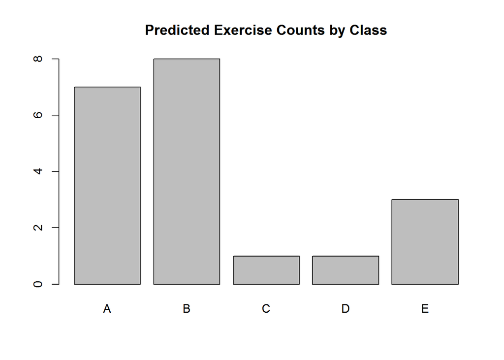

```r
plot(data_testing_model, main="Predicted Exercise Counts by Class")
```

Description of the five different classes was found on the original study’s website:

“*Six young health participants were asked to perform one set of 10 repetitions of the Unilateral Dumbbell Biceps Curl in five different fashions: exactly according to the specification (Class A), throwing the elbows to the front (Class B), lifting the dumbbell only halfway (Class C), lowering the dumbbell only halfway (Class D) and throwing the hips to the front (Class E).*” from http://groupware.les.inf.puc-rio.br/har

### Reference

Velloso, E.; Bulling, A.; Gellersen, H.; Ugulino, W.; Fuks, H. Qualitative Activity Recognition of Weight Lifting Exercises. Proceedings of 4th International Conference in Cooperation with SIGCHI (Augmented Human ’13) . Stuttgart, Germany: ACM SIGCHI, 2013. http://groupware.les.inf.puc-rio.br/har